# Tidy and compile bird data to 2024 for ESAI

Fiona Burns

Code adapted from script ‘01-tidy_bird_d4ato22.Rmd’, in notebook ‘rstudio-indeengto22’

This script:

- Brings together datasets of England-scale bird species’ time-series
- It consolidates their formats to allow merging and selects a single time-series per species
- It removes data deficient species and does some data processing to allow the time-series to be combined into an abundance indicator

### Load libraries

```r
library(reshape);library(reshape2);library(plyr);library(dplyr);library(ggplot2);library(stringr);library(readxl);library(tidyverse); library(lubridate); library(tidyverse); library(readxl)
```

### Load tidying functions

```r
source("/data/notebooks/rstudio-esaiukpsi26/tidy_functions.R")
```

# LOAD DATA

- Get bird datasets into consistent format
- Process so have consistent column titles, scientific_name, common_name, index, year, country, index_sm
- Add species names where missing
- Change all characters to lowercase

## Load bird datasets

Read in as lower case column names and lower case character fields

```r
#WILD BIRD INDICATOR
wbi <- read.csv("/data/species-timeseries/birds/all_species_indices_7024.csv") %>%
  set_names(tolower) %>%
  mutate(across(where(is.character) | where(is.logical), ~ tolower(as.character(.))))

colnames(wbi)[1] <- "x" #rename column 1 to x
#read in the datasource for each species as data from many surveys contribute to the WBI
wbi_source <-
  read_excel("/data/species-timeseries/birds/Allspecies_england_unsmooth_7022.xls",
             sheet = "SP_SOURCES") %>%
  mutate(spcode = ifelse(nchar(spcode) < 5, paste(spcode, ".", sep = ""),
                         as.character(spcode)))
#a few species have four letters but no '.' to make them into five letter codes, creates matching errors


#WINTERING WATERBIRD INDICATOR
wwbi    <-
  read.csv("/data/species-timeseries/birds/Defra_Indicators_Win_Waterbirds_Output2a_Species_Indices.csv") %>%
  set_names(tolower) %>%
  mutate(across(where(is.character) | where(is.logical), ~ tolower(as.character(.))))


#RARE BREEDING BIRDS PANEL
rbbp_uk_4c <-
  read_excel("/data/species-timeseries/birds/RBBP country totals 1973 to 2023_ME.xlsx",
                         sheet = "RBBP country totals 1973 to 202")%>%
  set_names(tolower) %>%
  mutate(across(where(is.character) | where(is.logical), ~ tolower(as.character(.))))


#SCARABBS
scar_mae   <-
  read.csv("/data/species-timeseries/birds/SCARABBS data for four countries for SoN 2023.csv")%>%
  set_names(tolower) %>%
  mutate(across(where(is.character) | where(is.logical), ~ tolower(as.character(.))))

#BREEDING BIRD SURVEY
bbs <-
  read.delim("/data/species-timeseries/birds/BTOBirdTrendsFigure_Gadwall_Long-term trend (1994–)_England.txt",
             comment.char="#") %>%
  full_join(
    read.delim("/data/species-timeseries/birds/BTOBirdTrendsFigure_Wheatear_Long-term trend (1994–)_England.txt",
               comment.char="#"))%>%
  set_names(tolower) %>%
  mutate(across(where(is.character) | where(is.logical), ~ tolower(as.character(.))))
```

[output not shown]

```r
# UPLAND BIRD INDICATOR
upind<-read.csv("/data/species-timeseries/birds/upland_species_indices_9424_revised.csv")%>%
  set_names(tolower) %>%
  mutate(across(where(is.character) | where(is.logical), ~ tolower(as.character(.))))
```

## Load auxilliary files

```r
#FILE WITH CONVERSION OF TWO LETTER/ FIVE LETTER BTO CODES TO SPECIES NAMES
BTOCode             <- read.csv("/data/species-timeseries/birds/BTOBirdList_withCodes.csv")%>%
  set_names(tolower) %>%
  mutate(across(where(is.character) | where(is.logical), ~ tolower(as.character(.))))

BTOCode <- BTOCode %>%
  mutate(across(c(common_name:scientific_name_in_hbw4, fiveletter), ~ str_to_lower(.x))) %>%
  mutate(five_letter = gsub("\\.", "", as.character(fiveletter)),
         two_letter  = gsub("\\.", "_", as.character(twoletter))) %>%
  filter(!(common_name == "stonechat" & fiveletter == "stoch")) #two rows included for Stonechat

#FILE WITH YEARS OF NATIONAL SURVEYS THAT CONFOUND RBBP TIMESERIES
rbbp_yrs_rm <- read.csv("/data/species-timeseries/birds/rbbp_yrs_to_rm_26.csv") %>%
  mutate(common_name = str_to_lower(common_name))

#FILE WITH DATA SOURCE FOR UPLAND INDICATOR TO SELECT ONLY THOSE WITH all HABITAT BBS TRENDS or NATIONAL SURVEYS
upland_src <- read_excel("/data/species-timeseries/birds/data_sources_enguk_2025.xlsx", sheet = "Sheet1") %>%
    rename_with(tolower) %>%
  mutate(across(where(is.character), tolower))
```

## Process datasets

- Filter to England only data and ensure a single time-series per species per dataset
- Melt files to dataframe format
- Get consistent column names and remove any auxilliary columns
- Some minor duplication in WBI file. have raised with BTO, here we have selected time-series going back to 1970

ENGLAND WILD BIRD INDICATORS

```r
## Extract unsmoothed index, smoothed index,uncertainty measures, year, and species ID  for all species
dup <- wbi %>%
  filter(country == "england") %>%
  group_by(species, year) %>%
  mutate(n = n()) %>%
  filter(n > 1) %>%
  ungroup()

wbi_m <- wbi %>%
  filter(country == "england") %>%
  rename(common_name = species, two_letter = spp2ltr, five_letter = code5ltr,
         index = unsmoothed, index_sm = smoothed_index)  %>%
  mutate(five_letter =  BTOCode$fiveletter[match(two_letter, BTOCode$twoletter)]) %>%
  #use two letter to add five letter code form BTOCode as in WBI file
  #greylag has NA for five letter code and
  #stonechat has a mismatch WBI/BTOCode as two five letter codes are available for this species
  mutate(source = wbi_source$survey[match(five_letter, wbi_source$spcode)]) %>%

  #need to deal with duplication of yellow wag, lapwing and reed bunting in WBI dataset
  #use column 'X' to do so as only way to distinguish the two time-series present per species
  #waterways BBS joint trend was included as well as CBC/BBS trend
  filter(!(common_name == "lapwing" & x < 30000), #data runs from 33116 - 38512
         !(common_name == "yellow wagtail" & x > 8000), #data runs from 7165 - 7701
         !(common_name == "reed bunting" & x > 12000 )) %>%  #data runs from 10463 - 11009
  select(scientific_name, common_name, two_letter, five_letter, source, year, index, index_sm) %>%
  as.data.frame()

wbi_m %>%
  reframe(across(1:6, ~ table(is.na(.x)))) # no NAs in any of the name columns or year barring redpoll
```

```
##   scientific_name common_name two_letter five_letter source year
## 1            5714        5714       5714        5659   5659 5714
## 2            5714        5714       5714          55     55 5714
```

```r
#check removal of duplicates has worked
wbi_m %>%
  group_by(common_name, year) %>%
  mutate(n = n()) %>%
  filter(n > 1)
```

```
## # A tibble: 0 × 9
## # Groups:   common_name, year [0]
## # ℹ 9 variables: scientific_name <chr>, common_name <chr>, two_letter <chr>,
## #   five_letter <chr>, source <chr>, year <int>, index <dbl>, index_sm <dbl>,
## #   n <int>
```

```r
#no duplication now
```

OTHER DATASETS

```r
#WWBI
# Reformat date column to year for wintering water birds and filter to only include England data
wwbi_m <- wwbi %>%
  filter(country == "england", subgroup == "all") %>%  # Keep only rows where country is 'england'
  mutate(year = year(ymd(date))) %>%
  rename(common_name = english_name,
         two_letter = two_character, five_letter = five_character,
         index = unsmoothed_index, index_sm = smoothed_index) %>%
  select(two_letter, five_letter, year, index, index_sm)#, scientific_name, common_name)
#goose names not matching up to BTOCode file.
#Could either amend names in one or other,
#or remove scientific and common names from wwbi_m file and match on two letter codes,
#Take latter approach

#RARE BREEDING BIRD PANEL
rbbp_m <- rbbp_uk_4c %>%
  filter(country == "england" ,
         `to_be_used_for_trends?` != "no") %>%
  select( -years_of_data, -`years_>0`,
         -`%_present`,  -`to_be_used_for_trends?`,
         -coverage_2014_assessment,-no., -country) %>% #
  as.data.frame() %>%
  reshape2::melt(id.vars = c("common_name", "scientific_name","count_unit", "notes", "2020_lockdown_impact"),
       variable.name = "year") %>%
  dplyr::rename(index = value, measure = notes) %>%
  mutate(year = as.numeric(gsub("x", "", as.character(year)))) %>%
  left_join(rbbp_yrs_rm) %>% #add info on national survey years to remove
  mutate(scientific_name = ifelse(scientific_name == "regulus ignicapillus",
                                  "regulus ignicapilla", as.character(scientific_name)))
#BREEDING BIRD SURVEY
bbs_m  <- bbs %>%
dplyr::select(common_name = english_name, year = year,
              index = unsmoothed_estimate, index_sm = smoothed_estimate,
              lcl_sm = smoothed_lower_ci, ucl_sm = smoothed_upper_ci) %>%
   mutate(common_name = str_to_lower(common_name))

#SCARRABS/ SBBS
scar_m <- scar_mae %>%
  filter(country == "england", is.na(relevant.)) %>%
  select(-country, -relevant.) %>%
  reshape2::melt(id.vars = c("species", "notes"), variable.name = "year") %>%
  dplyr::rename(common_name = species, index = value, notes = notes) %>%
  mutate(year = as.numeric(gsub("x", "", as.character(year)))) %>%
  filter(grepl("rbbp", as.character(notes)) == FALSE)  # remove species where notes suggest RBBP is better

up_m <- upind %>%
  filter(country == "england") %>%
  rename (common_name = english_name, two_letter = code2ltr,
  index = unsmoothed, index_sm = smoothed) %>%
  select(scientific_name, common_name, two_letter, year, index, index_sm) %>%
  mutate(source = upland_src$data_source[match(common_name, upland_src$common_name)],
         inc_eng = upland_src$include_in_eng[match(common_name, upland_src$common_name)]) %>%
  mutate(source = ifelse(two_letter == "pw", "upland bbs squares", source)) %>%
  filter(source == "all bbs squares" & inc_eng == "y"|
           source == "national surveys" & inc_eng == "y")
#filter to species with all bbs squares or national survey as 'data_source'
#don't want to use upland only trends
```

## Aggregate datasets

Stick the datasets into a list

```r
bird_l <- list(wbi = wbi_m, wwbi = wwbi_m, rbbp = rbbp_m, scar = scar_m, bbs = bbs_m, up = up_m) #sbi=smp_m,
```

Function to look up and add scientific_name and common name where not already present

```r
sci_n <- function(data) {

if(length(grep("scientific_name", as.character(names(data)))) == 0) {
  #if already scientific name column don't try to add it again
  sc_source<- matrix(0, nrow(data), 1)

   #match the different 'name' columns of the bird datasets to btocode to get scientific name
if(length(grep("common_name", as.character(names(data))) ) > 0) {
   c_s = as.character(BTOCode$scientific_name[match(data$common_name,
                                                    BTOCode$common_name)] )
  sc_source <- cbind(sc_source, c_s)
  }
if(length(grep("two_letter", as.character(names(data))) ) > 0) {
 tl_s = as.character(BTOCode$scientific_name[match(data$two_letter,
                                                   BTOCode$twoletter)] )
 sc_source <- cbind(sc_source, tl_s)
}
if(length(grep("five_letter", as.character(names(data))) ) > 0) {
  fl_s = as.character(BTOCode$scientific_name[match(data$five_letter,
                                                    BTOCode$five_letter)] )
  sc_source <- cbind(sc_source, fl_s)
}

   #get scientific name concensus from one or more columns of sc_source
 if(ncol(sc_source) == 2) {data$scientific_name <- as.character(sc_source[, 2])  }
 if(ncol(sc_source) == 3) {data$scientific_name <- ifelse(is.na(sc_source[, 2]),
                                                      as.character(sc_source[, 3]),
                                                      as.character(sc_source[, 2]))}
 if(ncol(sc_source) == 4) {data$scientific_name <- ifelse(is.na(sc_source[, 2] &
                                                                  is.na(sc_source[, 3],
                                                                        sc_source[, 4],
                              ifelse(is.na(sc_source[, 2], sc_source[, 3],
                                           sc_source[, 2])))))}
}

   #add in updated scientific name
data$scientific_name_hbw4 <-
  ifelse(is.na(match(data$scientific_name,BTOCode$scientific_name_in_hbw4)),
         BTOCode$scientific_name_in_hbw4[match(data$scientific_name, BTOCode$scientific_name)],
         BTOCode$scientific_name_in_hbw4[match(data$scientific_name, BTOCode$scientific_name_in_hbw4)])


    #add common name if not already present
 if(length(grep("common_name", as.character(names(data))) ) == 0) {
   data$common_name <-
     ifelse(is.na(data$scientific_name_hbw4),
            BTOCode$common_name[match(data$scientific_name, BTOCode$scientific_name)],
            BTOCode$common_name[match(data$scientific_name_hbw4, BTOCode$scientific_name_in_hbw4)])
 }

  #add column to say whether native species or not
  data$uk_spp <-
    ifelse(is.na(data$scientific_name_hbw4),
          BTOCode$british_species_bocc[match(data$scientific_name, BTOCode$scientific_name)],
          BTOCode$british_species_bocc[match(data$scientific_name_hbw4, BTOCode$scientific_name_in_hbw4)])
 return(data)
 }
```

## Add scientific and common names

Run sci_n function across dataframes

```r
bird_l1 <- bird_l %>%
  llply(sci_n)
#any species without scientific names?
bird_l1 %>%
  ldply(function(x) table(is.na(x$scientific_name)))
```

```
##    .id FALSE
## 1  wbi  5714
## 2 wwbi  1934
## 3 rbbp  2538
## 4 scar   432
## 5  bbs    62
## 6   up   211
```

# DATA CLEANING

Data cleaning required for different datasets

- All: Remove non-native species
- All: Remove species with no data or only zero counts
  - Remove years without data
  - Remove time-series shorter than ten years
- Rbbp: remove national survey years and poor qual years specified in rbbp_yrs_to_rm, remove covid impact years
- Scar/rbbp: remove where the number of years with counts above zero equals 0 or 1, need median of at least three and max of at least ten after trend starts and at least ten years
- Rbbp: for colonising/reintroduced species include time-series from where consistent run of positive counts begin

### Filter out non-native species

```r
llply(bird_l1, function(x) unique(x$common_name[x$uk_spp == "n"|is.na(x$uk_spp)]))
```

```
## $wbi
## character(0)
##
## $wwbi
## character(0)
##
## $rbbp
## [1] "ruff"
##
## $scar
## character(0)
##
## $bbs
## character(0)
##
## $up
## [1] "red grouse"
```

- Retain ruff, is native species, just matching issue, also red grouse (now endemic species Lagopus scotica)
- Filter to native species
- Retain former breeders golden oriole and wryneck

```r
bird_l1$rbbp <- bird_l1$rbbp %>%
  mutate(uk_spp = ifelse(is.na(uk_spp), "y", as.character(uk_spp)))

bird_l1$up <- bird_l1$up %>%
  mutate(uk_spp = ifelse(is.na(uk_spp), "y", as.character(uk_spp)))

bird_l2 <- bird_l1 %>%
  llply(function(x) filter(x, uk_spp == "y"| uk_spp == "former_breeder"))
```

- Red Grouse is now a full species (Lagopus scotica ), split from Lagopus lagopus. updated in upland Ind, but not WBI [or in our name conversion file]
- Here, as Red Grouse is replicated on both the WBI and Upland indicator datasets and we will use the WBI one it doesn’t matter that there is a name mismatch in the upland one
- Potential development option: Work in future years to update all our docs to the new global naming system for birds and map back to what’s used on SI.

### Remove data poor years for RBBP

- National survey years
- Covid impacted years

```r
bird_l2$rbbp <- bird_l2$rbbp %>%
  filter(is.na(reason_to_rm)) %>%
  mutate(`2020_lockdown_impact` = ifelse(is.na(`2020_lockdown_impact`),
                                  "low_unassessed",
                                  as.character(`2020_lockdown_impact`))) %>%
  filter(!(`2020_lockdown_impact` == "moderate" & year == 2020),
         !(`2020_lockdown_impact` == "high" & year == 2020),
         !(`2020_lockdown_impact` == "very high" & year == 2020)) %>%
  select(-reason_to_rm, -source)
```

Tidy up objects

```r
rm(rbbp_uk_4c, wbi, wwbi, scar_mae, bbs, upind)
```

##### Functions now in the ‘tidy_functions.Rmd’ script

- function to remove species with no data all NAs or a comb of NAs and zeros [no_data]
- function to remove years with no data [no_data_yr]
- function to remove very rare species [scarce_data]
- function to remove species with a year range of less than ten years [rm_dpoor]

### Remove data poor species/years

Run no_data_yr, no_data and rm_dpoor

```r
bird_l3 <- llply(bird_l2, no_data) %>%
  llply(no_data_yr) %>%
  llply(rm_dpoor)
#How many unique bird common names are in each dataset?
res2 <- ldply(bird_l2, \(x) dplyr::n_distinct(x$common_name))
res3 <- ldply(bird_l3, \(x) dplyr::n_distinct(x$common_name))
print(res2)
```

```
##    .id  V1
## 1  wbi 118
## 2 wwbi  41
## 3 rbbp  47
## 4 scar   8
## 5  bbs   2
## 6   up   7
```

```r
print(res3)
```

```
##    .id  V1
## 1  wbi 118
## 2 wwbi  41
## 3 rbbp  47
## 4 scar   8
## 5  bbs   2
## 6   up   7
```

```r
#no species removed SM
```

Run scarce_data for datasets with absolute numbers of birds, rather than indices

```r
bird_l3$rbbp <- scarce_data(bird_l3$rbbp) #11 rbbp species removed
bird_l3$scar <- scarce_data(bird_l3$scar) #1 scar species removed
ldply(bird_l3, function(x) n_distinct(x$common_name))
```

```
##    .id  V1
## 1  wbi 118
## 2 wwbi  41
## 3 rbbp  36
## 4 scar   7
## 5  bbs   2
## 6   up   7
```

```r
rbbp_rem_species <- setdiff(bird_l2$rbbp$common_name, bird_l3$rbbp$common_name)
#rm 11 rbbp species in total, 36 left, rm one scar
scar_rem_species <- setdiff(bird_l2$scar$common_name, bird_l3$scar$common_name)
#chough
print(rbbp_rem_species)
```

```
##  [1] "whooper swan"         "common scoter"        "common goldeneye"
##  [4] "slavonian grebe"      "white-tailed eagle"   "red-necked phalarope"
##  [7] "wood sandpiper"       "wryneck"              "fieldfare"
## [10] "redwing"              "black-winged stilt"
```

- Checked species removed and happy - RBBP/SCAR 05/02/2026

### Colonising species

Check if any colonising species have initial intermittent counts

- Wait until five consecutive positive counts, like for BoCC
- Rm cattle egret, five of ten years of data are zero counts, first year with five year run of positive counts is 2017. NOT on SI

Following discussion with BTO and RBBP

- RBBP shared extra data on confirmed breeding from ‘coloniser data’ file,
- Agreed should base start date on ‘confirmed breeding’ rather than max pairs

Here we take the first year of the first run of five consecutive years of confirmed breeding. So, we start:

- Spoonbill at 2010, rather than 89
- Osprey starts from 2000, rather than 97
- Crane stays starting at 1981
- Great white egret start from 2012 rather than 2010
- Med Gull and Little Egret already in WBI, but for completion
- Med Gull starts in 79 not 76, and LEgret in 96 not 93

Potential development option: Another defensible option would be to start after the first five consecutive years of breeding

- The assumption being that the species is part of the breeding avifauna by then
- This would mean that spoonbill and GWE had fewer than ten years of data currently

```r
bird_l3$rbbp <- bird_l3$rbbp %>%
  filter(common_name != "cattle egret") %>%
  mutate(index = ifelse(common_name == "eurasian spoonbill" & year < 2010|
                        common_name == "little egret" & year < 1996|
                        common_name == "meditarrean gull" & year < 1979|
                        common_name == "great white egret" & year < 2012|
                        common_name == "osprey" & year < 2000, NA, index))
```

Check number of species per dataset

```r
sapply(bird_l1, function(x) n_distinct(x$common_name))
```

```
##  wbi wwbi rbbp scar  bbs   up
##  118   41   47    8    2    7
```

```r
sapply(bird_l3, function(x) n_distinct(x$common_name))
```

```
##  wbi wwbi rbbp scar  bbs   up
##  118   41   35    7    2    7
```

```r
sapply(bird_l3, function(x) n_distinct(x$scientific_name))
```

```
##  wbi wwbi rbbp scar  bbs   up
##  118   41   35    7    2    7
```

# TIDY DATA

For the species remaining make sure data are in the correct format to combine in a composite species index The ‘tidying required’ function produces a df giving the number of species where:

- There are NAs at the start/within/at the end of species’ time-series
- There are zeros at the start/within/at the end of species’ time-series
- Are there missing rows in the time-series

## Tidying required

Run tidy report function on list of datasets and save

```r
bird_tr  <- llply(bird_l3, tidying_rqd)
```

```r
bird_tr1 <- ldply(bird_tr)
write.csv(bird_tr1[, c(".id", "test", "Fail", "Pass")],
          file = "/data/tidy_data/intermediate_files/tidy_rpt_bird_engto24_120326.csv", row.names = FALSE)
```

## Tidying

The ‘bird_tidy’ functions allows user defined processing of datasets to:

- Add rows for missing species years (exp.g)
- Convert zeros at the start of time-series to NAs (zero_st)
- Where zeros are present within time-series add 1% of the average value of a species’ time-series to all elements of it (zero_in)
- Use linear interpolation to fill in NAs within species’ time-series (interp)
- Hold final time-series values constant where they end before the final year of other species (exp_tail)

#### Run tidying function across list of datasets

Here we are processing the datasets ready for the Freeman model. So we need to:

- Remove zeros at the start of time-series
- Add 1% of mean ts value to all elements where >=1 elements == 0

```r
bird_tidy <- list(0)
for(i in 1:length(bird_l3)) {
  bird_tidy[[i]]     <- tidy_d(bird_l3[[i]], bird_tr[[i]], exp.g = "N", zero_st = "Y", zero_in = "Y")
}
```

Check again if some species have shorter than a ten year span

```r
bird_tidy1        <- llply(bird_tidy, rm_dpoor)
names(bird_tidy1) <- names(bird_l)
sapply(bird_tidy, function(x) n_distinct(x$common_name))
```

```
## [1] 118  41  35   7   2   7
```

```r
sapply(bird_tidy1, function(x) n_distinct(x$common_name)) # no difference 05/02/26
```

```
##  wbi wwbi rbbp scar  bbs   up
##  118   41   35    7    2    7
```

Convert list to single dataframe and tidy up columns

```r
bird_tdf  <- ldply(bird_tidy1);names(bird_tdf)
```

```
##  [1] ".id"                  "scientific_name"      "common_name"
##  [4] "two_letter"           "five_letter"          "source"
##  [7] "year"                 "index"                "index_sm"
## [10] "scientific_name_hbw4" "uk_spp"               "index_orig"
## [13] "count_unit"           "measure"              "2020_lockdown_impact"
## [16] "notes"                "lcl_sm"               "ucl_sm"
## [19] "inc_eng"
```

```r
bird_tdf1 <- bird_tdf %>%
  select(.id, common_name, scientific_name, scientific_name_hbw4,
        source,  year, index, index_sm, lcl_sm, ucl_sm, index_orig, uk_spp)
```

Check if any latin names are matched with more than one common name and vice versa

```r
cn_per_sc <- ddply(bird_tdf1, .(scientific_name), summarise, ncn = length(unique(common_name)))
cn_per_sc[cn_per_sc$ncn > 1, ]
```

```
##         scientific_name ncn
## 27        aythya ferina   2
## 57    coturnix coturnix   2
## 81          fulica atra   2
## 123 phalacrocorax carbo   2
```

```r
sn_per_cn <- ddply(bird_tdf1, .(common_name), summarise, nsn = length(unique(scientific_name)))
sn_per_cn[sn_per_cn$nsn > 1, ]
```

```
##            common_name nsn
## 6         black grouse   2
## 38    dartford warbler   2
## 96  mediterranean gull   2
## 116         red grouse   2
## 139           shoveler   2
```

Five common names and linked to two separate scientific names

- black grouse
- red grouse
- dartford warbler
- mediterranean gull
- shoveler

Four latin names and linked to two separate common names, usually just addition of ‘common’ or similar prefix

- Aythya ferina
- Coturnix coturnix
- Fulica atra
- Phalacrocorax carbo

#### Select a single common and scientific name per species

```r
bird_tdf1 <- bird_tdf1 %>%
  mutate(scientific_name = ifelse(common_name == "shoveler", "anas clypeata",
                              ifelse(common_name == "dartford warbler", "curruca undata",
                                     ifelse(common_name == "mediterranean gull", "ichthyaetus melanocephalus",
                                            ifelse(common_name == "red grouse", "lagopus scotica",
                                                   ifelse(common_name == "black grouse", "lyrurus tetrix", scientific_name))))),
           common_name =   ifelse(scientific_name == "aythya ferina", "pochard",
                                  ifelse(scientific_name == "coturnix coturnix", "quail",
                                        ifelse(scientific_name == "fulica atra", "coot",
                                           ifelse(scientific_name == "phalacrocorax carbo", "cormorant",
                                         as.character(common_name))))))
```

- check this has worked

```r
cn_per_sc <- ddply(bird_tdf1, .(scientific_name), summarise, ncn = length(unique(common_name)))
cn_per_sc[cn_per_sc$ncn > 1, ]
```

```
## [1] scientific_name ncn
## <0 rows> (or 0-length row.names)
```

```r
sn_per_cn <- ddply(bird_tdf1, .(common_name), summarise, nsn = length(unique(scientific_name)))
sn_per_cn[sn_per_cn$nsn > 1, ]
```

```
## [1] common_name nsn
## <0 rows> (or 0-length row.names)
```

- save compiled data

```r
write.csv(bird_tdf1, file = "/data/tidy_data/intermediate_files/full_tidydata_bird_engto24_120326.csv", row.names = FALSE)
```

# SELECT SINGLE TS PER SPECIES

### Define best data

Summarise which data are available per species and then select heirarchically

Heirarchy = sbi > wbi > up >SCARRABS > RBBP > WaterbirdIndex

```r
bird_sum <- bird_tdf1 %>%
  group_by(scientific_name, .id) %>%
  summarise(
    data_av = sum(!is.na(index))) %>%
  mutate(
    .id = factor(.id, levels = c( "wbi", "up", "scar", "rbbp", "bbs", "wwbi")), #"sbi",
    rnk = as.numeric(.id)
  )
```

Filter out species time-series that do not correspond to the minimum rank per species

```r
bird_sum_sh <- bird_sum %>%
  group_by(scientific_name) %>%
  mutate(min_rnk = min(rnk, na.rm = TRUE)) %>%
  filter(rnk == min_rnk)

#any species with more than one row?
bird_sum_sh %>%
  group_by(scientific_name) %>%
  summarise(n = n()) %>%
  filter(n > 1) #No
```

```
## # A tibble: 0 × 2
## # ℹ 2 variables: scientific_name <chr>, n <int>
```

Save list of which survey to use per species

```r
write.csv(bird_sum_sh, file = "/data/tidy_data/intermediate_files/bird_bestdata_engto24_120326.csv", row.names = FALSE)
```

### Select best data

Filter total dataset to only have top ranked survey per species

```r
bird_tdf_sh <- bird_tdf1 %>%
  mutate(best_d = bird_sum_sh$.id[match(paste(.id, scientific_name), paste(bird_sum_sh$.id, bird_sum_sh$scientific_name))]) %>%
  filter(!is.na(best_d))
```

### Deal with geese

Geese are a particularly tricky group as they are monitored at a race level and some species have both native and feral populations

The taxa on the SI are at species level, so we may need to average across time-series for different races

- The taxa on the S41 list are at race level
- So the S41 list is NOT a subset of the SI

#### What Goose data do we have?

```r
bird_tdf_sh$scientific_name <- as.character(bird_tdf_sh$scientific_name)

geese <- bird_tdf_sh[grep("goose", as.character(bird_tdf_sh$common_name)), ]

table(geese$best_d, geese$scientific_name)
```

```
##
##        anser albifrons subsp. albifrons anser anser (british/irish)
##   wbi                                 0                           0
##   up                                  0                           0
##   scar                                0                           0
##   rbbp                                0                           0
##   bbs                                 0                           0
##   wwbi                               49                          49
##
##        anser brachyrhynchus branta bernicla subsp. bernicla
##   wbi                     0                               0
##   up                      0                               0
##   scar                    0                               0
##   rbbp                    0                               0
##   bbs                     0                               0
##   wwbi                   49                              49
##
##        branta bernicla subsp. hrota s
##   wbi                               0
##   up                                0
##   scar                              0
##   rbbp                              0
##   bbs                               0
##   wwbi                             49
```

Data available, updated 2026

- Anser brachyrhynchus wwbi
- Anser albifrons subsp. albifrons wwbi
- Anser anser (British/Irish) wwbi
- Branta bernicla subsp. bernicla wwbi
- Branta bernical subsp. Hrota S wwbi

On S41 (priority sp) list

- Branta bernicla bernicla
- Anser Albifrons albifrons

On SI (all species) list - all at species level

- Anser anser (greylag)
- Anser brachyrhynchus (pink foot)
- Anser albifrons (white-fronted)
- Branta bernicla (combined subsp. bernicla and Hrota S) (Brent)

Action required

- S41 list
  - Retain Branta bernicla subsp. bernicla and A. alb alb for S41
- SI list
  - Add copy of Anser albifrons subsp. albifrons at specific level for SI
  - Average Branta bernicla subsp for SI (all sp list)
  - After averaging, remove Branta bernicla subsp. Hrota S as not needed at sub-spp level

#### Averaging across species time-series

We need to calculate an average time series for geese with more than one survey available First we need to assess whether any processing is needed to allow us to use a basic geometric mean, or the IndFun function, which allows for staggered entry

##### Functions now in ‘tidying_functions.Rmd’ script

- function to rescale ts relative to first value [rescale]
- function to calculate geometric mean [geometric]
- function to calculate indicator, which requires a dataframe of species indices where each row is a species year combination [indFun1]

#### Tabulate processing needed (copied from UK script SM 2026 )

- When do they start and end and what is the first value of each time-series
- Do they have missing values?

```r
geese_summary <- geese %>%
  group_by(common_name) %>%
  summarise(across(index:index_sm, ~ min(year[!is.na(index)]), .names = "min_{.col}"),
            across(index:index_sm, ~ max(year[!is.na(index)]), .names = "max_{.col}"),
            yrs    = length(index[!is.na(index)]),
            fvalue = index[year == min(year[!is.na(index)], na.rm = TRUE)]) %>%
  ungroup() %>%
  mutate(dur = max_index - min_index) %>%
  mutate(missing = ifelse(yrs == (dur + 1), "N", "Y"))

# Print result
geese_summary
```

```
## # A tibble: 5 × 9
##   common_name   min_index min_index_sm max_index max_index_sm   yrs fvalue   dur
##   <chr>             <dbl>        <dbl>     <dbl>        <dbl> <int>  <dbl> <dbl>
## 1 brent goose …      1975         1975      2023         2023    48      5    48
## 2 dark-bellied…      1975         1975      2023         2023    48     38    48
## 3 european whi…      1975         1975      2023         2023    48    389    48
## 4 greylag goos…      1975         1975      2023         2023    48      3    48
## 5 pink-footed …      1975         1975      2023         2023    49     15    48
## # ℹ 1 more variable: missing <chr>
```

- All end in year 2023
- Not rescaled (fvalue is not 1 or 100)
- All have missing years apart from pink footed goose (Anser brachyrhynchus)

Which years are missing?

```r
geese %>%
  filter(((grepl("brent", common_name) == TRUE    & year == year[is.na(index)]|
          grepl("white-fronted", common_name) == TRUE) & year == year[is.na(index)]|
          grepl("greylag", common_name) == TRUE) & year == year[is.na(index)]|
          grepl("barnacle", common_name) == TRUE & year == year[is.na(index)])
```

```
##    .id                        common_name                  scientific_name
## 1 wwbi       european white-fronted goose anser albifrons subsp. albifrons
## 2 wwbi      greylag goose (british/irish)      anser anser (british/irish)
## 3 wwbi           dark-bellied brent goose  branta bernicla subsp. bernicla
## 4 wwbi brent goose (light-bellied of sval   branta bernicla subsp. hrota s
##   scientific_name_hbw4 source year index index_sm lcl_sm ucl_sm index_orig
## 1                 <NA>   <NA> 2020    NA       89     NA     NA         NA
## 2                 <NA>   <NA> 2020    NA      105     NA     NA         NA
## 3                 <NA>   <NA> 2020    NA       98     NA     NA         NA
## 4                 <NA>   <NA> 2020    NA       66     NA     NA         NA
##   uk_spp best_d
## 1      y   wwbi
## 2      y   wwbi
## 3      y   wwbi
## 4      y   wwbi
```

- Single missing year of 2020 for all sp except pink footed

Plot time series

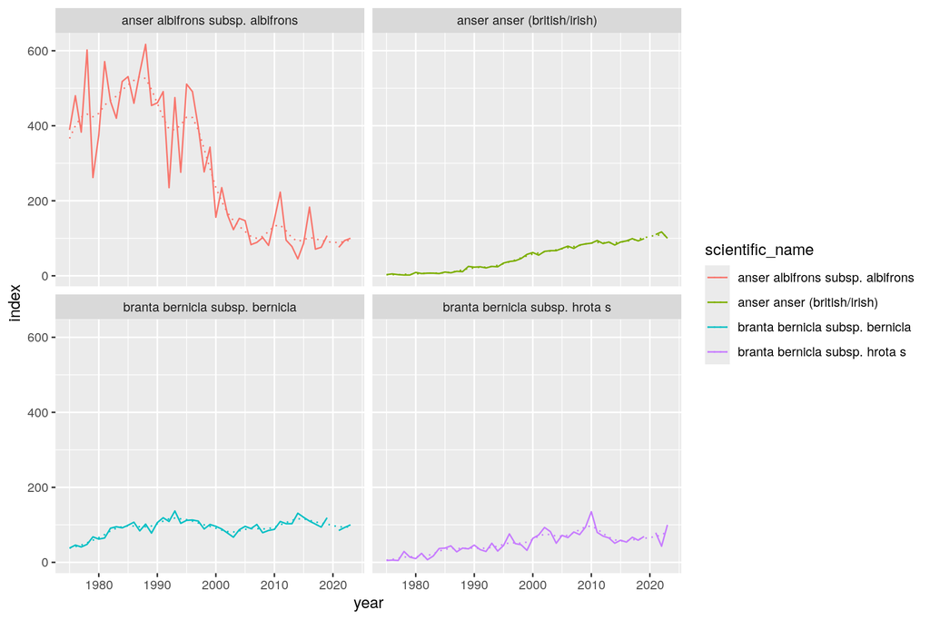

```r
geese1 <- geese %>%
  filter(scientific_name != "anser brachyrhynchus")

ggplot(geese1, aes(x = year, colour = scientific_name)) +
  geom_line(aes( y = index)) +
  geom_line(aes(y = index_sm), lty = 3) +
  facet_wrap(vars(scientific_name), nrow = 2)
```

#### Process goose time-series for averaging

Brent goose races, for both index and index_sm

```r
geese %>%
  filter(grepl("brent", common_name) == TRUE & year == year[is.na(index)])
```

```
##    .id                        common_name                 scientific_name
## 1 wwbi           dark-bellied brent goose branta bernicla subsp. bernicla
## 2 wwbi brent goose (light-bellied of sval  branta bernicla subsp. hrota s
##   scientific_name_hbw4 source year index index_sm lcl_sm ucl_sm index_orig
## 1                 <NA>   <NA> 2020    NA       98     NA     NA         NA
## 2                 <NA>   <NA> 2020    NA       66     NA     NA         NA
##   uk_spp best_d
## 1      y   wwbi
## 2      y   wwbi
```

Processing needed

- We have a single common missing year, so we do not need to interpolate over it
- We need to re-scale the ts to a common initial value
- As the two ts start in the same year, we can take a basic geomean rather than run IndFun, which controls for staggered entry
- We need to do this for both the ‘index’ and ‘index_sm’ columns

```r
b.b <- bird_tdf_sh[grep("branta bernicla", bird_tdf_sh$scientific_name), ] %>%
  rescale(ind_col = index, Index_root = 1) %>%
  rescale(ind_col = index_sm, Index_root = 1) %>%
  group_by(year) %>%
  summarise(across(index:index_sm, ~ geometric(.x))) %>% #throws an NaN in 2020 as missing year for both species
  mutate(index = ifelse(is.nan(index), NA, index)) %>% #change to NA
  mutate(scientific_name = "branta bernicla", common_name = "brent goose",
         .id = "wwbi", index_orig = NA)

#create copy of white front time-series and label at specific level
a.a <- bird_tdf_sh[grep("anser albifrons", bird_tdf_sh$scientific_name), ] %>%
  mutate(scientific_name = "anser albifrons", common_name = "white-fronted goose",
         .id = "wwbi", index_orig = index)

#remove brent subsp hrota and add copy of white front and brent at species level
#to the freeman dataset
bird_tdf_sh1 <- bird_tdf_sh %>%
  filter(!(scientific_name == "branta bernicla subsp. hrota s")) %>%
  full_join(b.b) %>%
  full_join(a.a)#add goose spp to dataset
```

[output not shown]

```r
rm(b.b, a.a)
```

Let’s plot that to see what the average trends look like

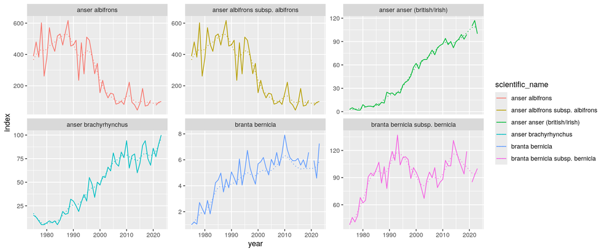

```r
geese_pro <- bird_tdf_sh1[grep("goose", as.character(bird_tdf_sh1$common_name)), ]

ggplot(geese_pro, aes(x = year, colour = scientific_name)) +
  geom_line(aes( y = index)) +
  geom_line(aes(y = index_sm), lty = 3) +
  facet_wrap(vars(scientific_name), nrow = 2, scales = "free_y")
```

# CHECKS

- Check for missing data

```r
bird_tdf_sh1 %>%
  summarise(sci = sum(is.na(scientific_name)), com = sum(is.na(common_name)), year = sum(is.na(year)), ind = sum(is.na(index)), sur = sum(is.na(.id)))
```

```
##   sci com year ind sur
## 1   0   0    0 547   0
```

- How many species per survey

```r
ddply(bird_tdf_sh1, .(.id), summarise,      n_distinct(scientific_name))
```

```
##    .id n_distinct(scientific_name)
## 1  bbs                           2
## 2 rbbp                          22
## 3 scar                           3
## 4   up                           5
## 5  wbi                         118
## 6 wwbi                          21
```

- Are there any duplicate spp yr combs?

```r
a1 <- bird_tdf_sh1 %>%
  group_by(scientific_name, year) %>%
  summarise(n = n())
a1[a1$n >1, ]
```

```
## # A tibble: 0 × 3
## # Groups:   scientific_name [0]
## # ℹ 3 variables: scientific_name <chr>, year <dbl>, n <int>
```

```r
b1 <- bird_tdf_sh1 %>%
  group_by(common_name, year) %>%
  summarise(n = n())
b1[b1$n >1, ]
```

```
## # A tibble: 0 × 3
## # Groups:   common_name [0]
## # ℹ 3 variables: common_name <chr>, year <dbl>, n <int>
```

- Nothing detected

A couple of species names are not proper latin names - Eider and Greylag, Bits in brackets not needed

```r
bird_tdf_sh1 <- bird_tdf_sh1 %>%
  mutate(scientific_name = gsub("\\s*\\([^\\)]+\\)","", scientific_name))
```

## Save final bird data file

```r
write.csv(bird_tdf_sh1, file = "/data/tidy_data/intermediate_files/bird_compiled_engto24_120326.csv",
          row.names = FALSE)
```

From comparison to the bird dataset running to 2023 - The species composition at this point is the same but with redpoll rather than lesser redpoll - All species have the same data sources barring change in seabirds